# Feature Engineering

Emanuele Costa

11/03/2019

```r
library(dplyr)
library(caret)
library(Metrics)
library(mice)
library(car)
library(rpart)
library(tree.bins)
```

## Feature Engineering

Feature engineering is the process of using domain knowledge of the data to create features that make machine learning algorithms work. Feature engineering is fundamental to the application of machine learning, and is both difficult and expensive. **The need for manual feature engineering can be obviated by automated feature learning.**

Feature engineering is an **informal topic**, but it is considered essential in applied machine learning.

*Coming up with features is difficult, time-consuming, requires expert knowledge. “Applied machine learning” is basically feature engineering.

Andrew Ng, Machine Learning and AI via Brain simulations*

## Precision, Recall and Accuracy

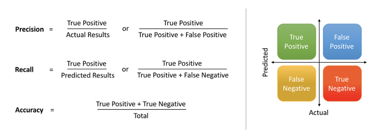

## Titanic Dataset

The sinking of the **RMS Titanic** is one of the most infamous shipwrecks in history. On April 15, 1912, during her maiden voyage, the Titanic sank after colliding with an iceberg, killing 1502 out of 2224 passengers and crew. This sensational tragedy shocked the international community and led to better safety regulations for ships.

One of the reasons that the shipwreck led to such loss of life was that there were not enough lifeboats for the passengers and crew. Although there was some element of luck involved in surviving the sinking, some groups of people were more likely to survive than others, such as women, children, and the upper-class.

We could ask ourselves what sorts of people were likely to survive. In particular, we could apply the tools of machine learning to predict which passengers survived the tragedy.

```r
train <- read.csv('train.csv', stringsAsFactors = F)
test <- read.csv('test.csv', stringsAsFactors = F)
test_labels <- test$PassengerId
test$Survived <- NA

str(train)
```

```
## 'data.frame':    891 obs. of  12 variables:
##  $ PassengerId: int  1 2 3 4 5 6 7 8 9 10 ...
##  $ Survived   : int  0 1 1 1 0 0 0 0 1 1 ...
##  $ Pclass     : int  3 1 3 1 3 3 1 3 3 2 ...
##  $ Name       : chr  "Braund, Mr. Owen Harris" "Cumings, Mrs. John Bradley (Florence Briggs Thayer)" "Heikkinen, Miss. Laina" "Futrelle, Mrs. Jacques Heath (Lily May Peel)" ...
##  $ Sex        : chr  "male" "female" "female" "female" ...
##  $ Age        : num  22 38 26 35 35 NA 54 2 27 14 ...
##  $ SibSp      : int  1 1 0 1 0 0 0 3 0 1 ...
##  $ Parch      : int  0 0 0 0 0 0 0 1 2 0 ...
##  $ Ticket     : chr  "A/5 21171" "PC 17599" "STON/O2. 3101282" "113803" ...
##  $ Fare       : num  7.25 71.28 7.92 53.1 8.05 ...
##  $ Cabin      : chr  "" "C85" "" "C123" ...
##  $ Embarked   : chr  "S" "C" "S" "S" ...
```

```r
train$PassengerId <- NULL
set.seed(1997)
```

### Data Dictionary

**pclass**: A proxy for socio-economic status (SES)

- 1st = Upper
- 2nd = Middle
- 3rd = Lower

**age**: Age is fractional if less than 1. If the age is estimated, is it in the form of xx.5

**sibsp**: The dataset defines family relations in this way…

- Sibling = brother, sister, stepbrother, stepsister
- Spouse = husband, wife (mistresses and fiances were ignored)

**parch**: The dataset defines family relations in this way…

- Parent = mother, father
- Child = daughter, son, stepdaughter, stepson
- Some children travelled only with a nanny, therefore parch=0 for them.

## Random Forest

Watch the youtube video below. For the video to appear you **NEED TO OPEN THE KNITTED HTML FILE IN A BROWSER LIKE FIREFOX/CHROME/IE**.

[video not shown]

## Exploratory Data Analysis (EDA)

```r
# Missing Values
sapply(train, function(X) sum(is.na(X)))
```

```
## Survived   Pclass     Name      Sex      Age    SibSp    Parch   Ticket
##        0        0        0        0      177        0        0        0
##     Fare    Cabin Embarked
##        0        0        0
```

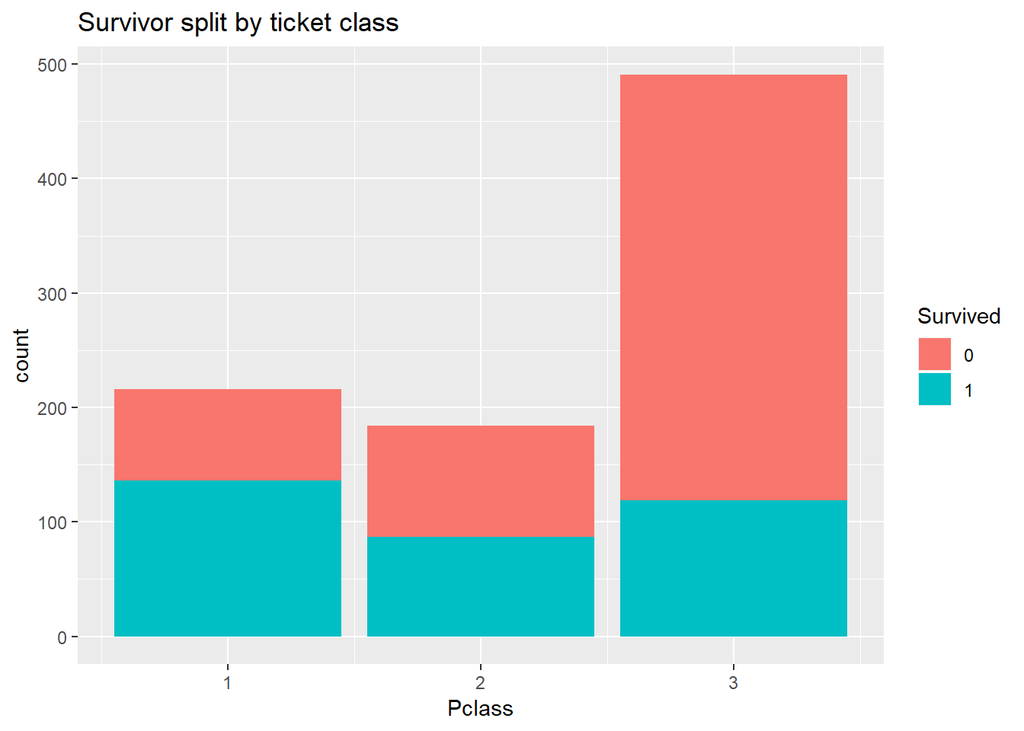

```r
# let's factorize categorical variables
train$Survived.F <- as.factor(train$Survived)
train$Survived <- NULL
train$Sex.F <- as.factor(train$Sex)
train$Sex <- NULL
train$Pclass.F <- as.factor(train$Pclass)
train$PClass <- NULL

# let's examine the three variables of interest

ggplot(train, aes(x=Pclass,fill=Survived.F)) + geom_bar() + labs(fill = "Survived") + labs(title="Survivor split by ticket class")
```

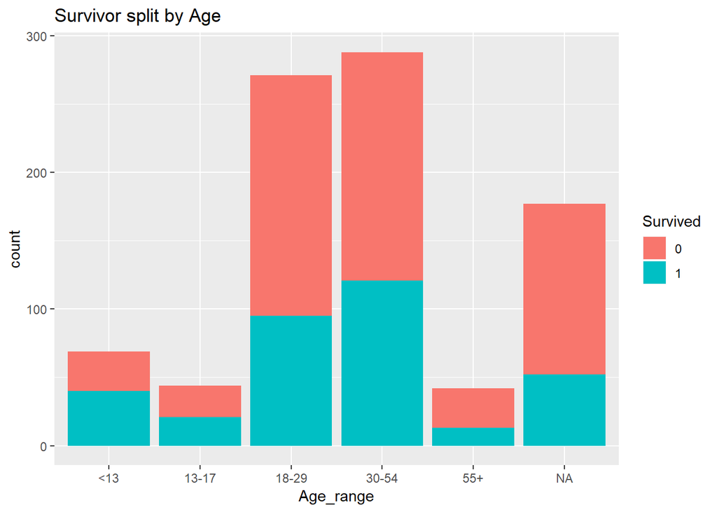

```r
agebrackets <- c(0,13,18,30,55)
train$Agebracket <- findInterval(train$Age,agebrackets)
agetable <- data.frame(Agebracket=c(1,2,3,4,5),Age_range=c("<13","13-17","18-29","30-54","55+"))
train.age <- merge(train,agetable,by="Agebracket", all=TRUE)
train.age$Agebracket <- as.factor(train$Agebracket)

ggplot(train.age, aes(x=Age_range,fill=Survived.F)) + geom_bar() + labs(fill = "Survived") + labs(title="Survivor split by Age")
```

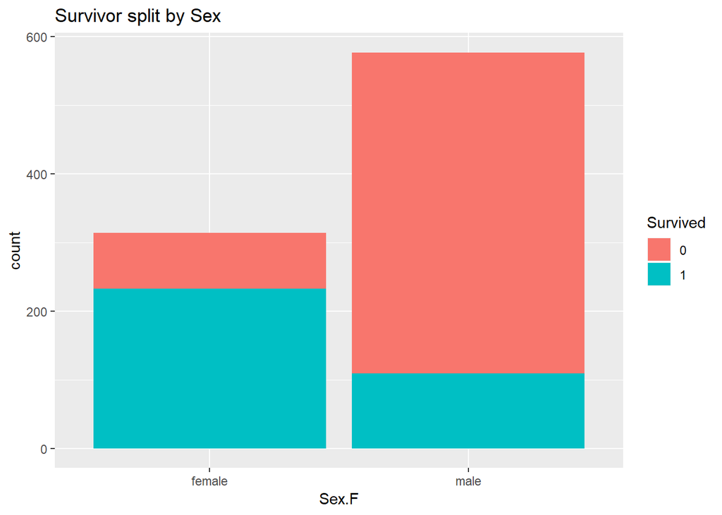

```r
train$Agebracket <- NULL
train.age <- NULL


ggplot(train, aes(x=Sex.F,fill=Survived.F)) + geom_bar() + labs(fill = "Survived") + labs(title="Survivor split by Sex")
```

```r
table(train$Cabin, useNA = 'always')
```

```
##
##                             A10             A14             A16
##             687               1               1               1
##             A19             A20             A23             A24
##               1               1               1               1
##             A26             A31             A32             A34
##               1               1               1               1
##             A36              A5              A6              A7
##               1               1               1               1
##            B101            B102             B18             B19
##               1               1               2               1
##             B20             B22             B28              B3
##               2               2               2               1
##             B30             B35             B37             B38
##               1               2               1               1
##             B39              B4             B41             B42
##               1               1               1               1
##             B49              B5             B50     B51 B53 B55
##               2               2               1               2
## B57 B59 B63 B66         B58 B60             B69             B71
##               2               2               1               1
##             B73             B77             B78             B79
##               1               2               1               1
##             B80         B82 B84             B86             B94
##               1               1               1               1
##         B96 B98            C101            C103            C104
##               4               1               1               1
##            C106            C110            C111            C118
##               1               1               1               1
##            C123            C124            C125            C126
##               2               2               2               2
##            C128            C148              C2         C22 C26
##               1               1               2               3
##     C23 C25 C27             C30             C32             C45
##               4               1               1               1
##             C46             C47             C49             C50
##               1               1               1               1
##             C52             C54         C62 C64             C65
##               2               1               1               2
##             C68              C7             C70             C78
```

[output cut: 22 more lines]

```
##               1               2               2               1
##             E33             E34             E36             E38
##               2               1               1               1
##             E40             E44             E46             E49
##               1               2               1               1
##             E50             E58             E63             E67
##               1               1               1               2
##             E68             E77              E8           F E69
##               1               1               2               1
##           F G63           F G73              F2             F33
##               1               2               3               3
##             F38              F4              G6               T
##               1               2               4               1
##            <NA>
##               0
```

```r
#table(train$Ticket, useNA = 'always')
train$Cabin[train$Cabin == ''] <- 'UN'
train$Cabin[train$Cabin != ''] <- substr(train$Cabin, 1 , 1)
table(train$Cabin)
```

```
##
##   A   B   C   D   E   F   G   T   U
##  15  47  59  33  32  13   4   1 687
```

```r
train$Cabin.F <- as.factor(train$Cabin)
```

## Train/Test split

Because only Kaggle has the real labels for the **test** set and we may want to validate some our **imputation** and **balancing** we split the **train** set into a **train.sub** and **validation.sub** datasets using a 80/20 ration.

```r
## 80% of the sample size
smp_size <- floor(0.80 * nrow(train))
train_ind <- sample(seq_len(nrow(train)), size = smp_size)

split_train_val <- function(X) {
  train.sub <- X[train_ind, ]
  validation.sub <- X[-train_ind, ]
  val_labels <- validation.sub$Survived.F
  validation.sub$Survived.F <- NULL
  return(list(train.sub, validation.sub, val_labels))
}
```

Notice this is our own train/test split and we are at mercy of randomness (how good/bad is this train/test split).

The R package caret later on will create many **folds** to balance the train/test split, please look at this video on **cross validation**:

[video not shown]

## ROC/AUC

[video not shown]

## First Logistic Regression

Let’s run a dummy regression with with the dataset **as it is** (simple imputation, no feature engineering). We cannot use the **Name** variable yet because it is effectively an ID (each row has a unique Name).

```r
# 4-fold CV
fitControl <- trainControl(
  method = "cv",
  number = 4,
  savePredictions = TRUE,
  verboseIter=TRUE
)

table(train$Age, useNA = "always")
```

```
##
## 0.42 0.67 0.75 0.83 0.92    1    2    3    4    5    6    7    8    9   10
##    1    1    2    2    1    7   10    6   10    4    3    3    4    8    2
##   11   12   13   14 14.5   15   16   17   18   19   20 20.5   21   22   23
##    4    1    2    6    1    5   17   13   26   25   15    1   24   27   15
## 23.5   24 24.5   25   26   27   28 28.5   29   30 30.5   31   32 32.5   33
##    1   30    1   23   18   18   25    2   20   25    2   17   18    2   15
##   34 34.5   35   36 36.5   37   38   39   40 40.5   41   42   43   44   45
##   15    1   18   22    1    6   11   14   13    2    6   13    5    9   12
## 45.5   46   47   48   49   50   51   52   53   54   55 55.5   56   57   58
##    2    3    9    9    6   10    7    6    1    8    2    1    4    2    5
##   59   60   61   62   63   64   65   66   70 70.5   71   74   80 <NA>
##    2    4    3    4    2    2    3    1    2    1    2    1    1  177
```

```r
## imputation we simply take the average age
train$AgeImp1<- ifelse(is.na(train$Age), round(mean(train$Age, na.rm=TRUE)), train$Age)
table(train$AgeImp1, useNA = "always")
```

```
##
## 0.42 0.67 0.75 0.83 0.92    1    2    3    4    5    6    7    8    9   10
##    1    1    2    2    1    7   10    6   10    4    3    3    4    8    2
##   11   12   13   14 14.5   15   16   17   18   19   20 20.5   21   22   23
##    4    1    2    6    1    5   17   13   26   25   15    1   24   27   15
## 23.5   24 24.5   25   26   27   28 28.5   29   30 30.5   31   32 32.5   33
##    1   30    1   23   18   18   25    2   20  202    2   17   18    2   15
##   34 34.5   35   36 36.5   37   38   39   40 40.5   41   42   43   44   45
##   15    1   18   22    1    6   11   14   13    2    6   13    5    9   12
## 45.5   46   47   48   49   50   51   52   53   54   55 55.5   56   57   58
##    2    3    9    9    6   10    7    6    1    8    2    1    4    2    5
##   59   60   61   62   63   64   65   66   70 70.5   71   74   80 <NA>
##    2    4    3    4    2    2    3    1    2    1    2    1    1    0
```

```r
ret <- split_train_val(train)
train.sub <- ret[[1]]
validation.sub <- ret[[2]]
val_labels <- ret[[3]]


## Logistic regression
lreg  <- train(Survived.F ~ AgeImp1 + Sex.F + Pclass.F,data=train.sub,method="glm",family=binomial(),trControl=fitControl)
summary(lreg)
```

```
##
## Call:
## NULL
##
## Deviance Residuals:
##     Min       1Q   Median       3Q      Max
## -2.6207  -0.6641  -0.3917   0.5730   2.3925
##
## Coefficients:
##              Estimate Std. Error z value Pr(>|z|)
## (Intercept)  3.462046   0.413828   8.366  < 2e-16 ***
## AgeImp1     -0.030456   0.008643  -3.524 0.000425 ***
## Sex.Fmale   -2.712007   0.213473 -12.704  < 2e-16 ***
## Pclass.F2   -0.967773   0.293698  -3.295 0.000984 ***
## Pclass.F3   -2.365504   0.273483  -8.650  < 2e-16 ***
## ---
## Signif. codes:  0 '***' 0.001 '**' 0.01 '*' 0.05 '.' 0.1 ' ' 1
##
## (Dispersion parameter for binomial family taken to be 1)
##
##     Null deviance: 943.08  on 711  degrees of freedom
## Residual deviance: 625.94  on 707  degrees of freedom
## AIC: 635.94
##
## Number of Fisher Scoring iterations: 5
```

```r
# let's now predict
lreg_pred <- predict(lreg, validation.sub)
confusionMatrix(lreg_pred, val_labels)
```

```
## Confusion Matrix and Statistics
##
##           Reference
## Prediction  0  1
##          0 94 29
##          1 11 45
##
##                Accuracy : 0.7765
##                  95% CI : (0.7084, 0.8353)
##     No Information Rate : 0.5866
##     P-Value [Acc > NIR] : 6.711e-08
##
##                   Kappa : 0.5221
##  Mcnemar's Test P-Value : 0.00719
##
##             Sensitivity : 0.8952
##             Specificity : 0.6081
##          Pos Pred Value : 0.7642
##          Neg Pred Value : 0.8036
##              Prevalence : 0.5866
##          Detection Rate : 0.5251
##    Detection Prevalence : 0.6872
##       Balanced Accuracy : 0.7517
##
##        'Positive' Class : 0
##
```

```r
auc_val <- auc(val_labels, lreg_pred)
print(auc_val)
```

```
## [1] 0.7516731
```

```r
train$AgeImp1 <- NULL
```

## Second Logistic Regression

In the first logistic regression we imputed **Age** in a quite “silly” way just taking the average. Can we do better to guess the real Age? Would this bring better out-sample predictions?

One approach could be to regress the Age according to some potentially predictive features and then **impute** the missing **NA** values using the predictions from this regression.

There is a lot in a name…

```r
tail(train[,c("Name","Age")], n=20)
```

```
##                                                 Name Age
## 872 Beckwith, Mrs. Richard Leonard (Sallie Monypeny)  47
## 873                         Carlsson, Mr. Frans Olof  33
## 874                      Vander Cruyssen, Mr. Victor  47
## 875            Abelson, Mrs. Samuel (Hannah Wizosky)  28
## 876                 Najib, Miss. Adele Kiamie "Jane"  15
## 877                    Gustafsson, Mr. Alfred Ossian  20
## 878                             Petroff, Mr. Nedelio  19
## 879                               Laleff, Mr. Kristo  NA
## 880    Potter, Mrs. Thomas Jr (Lily Alexenia Wilson)  56
## 881     Shelley, Mrs. William (Imanita Parrish Hall)  25
## 882                               Markun, Mr. Johann  33
## 883                     Dahlberg, Miss. Gerda Ulrika  22
## 884                    Banfield, Mr. Frederick James  28
## 885                           Sutehall, Mr. Henry Jr  25
## 886             Rice, Mrs. William (Margaret Norton)  39
## 887                            Montvila, Rev. Juozas  27
## 888                     Graham, Miss. Margaret Edith  19
## 889         Johnston, Miss. Catherine Helen "Carrie"  NA
## 890                            Behr, Mr. Karl Howell  26
## 891                              Dooley, Mr. Patrick  32
```

```r
train$Title <- gsub('(.*, )|(\\..*)', '', train$Name)
count(train,Title)
```

```
## # A tibble: 17 x 2
##    Title            n
##    <chr>        <int>
##  1 Capt             1
##  2 Col              2
##  3 Don              1
##  4 Dr               7
##  5 Jonkheer         1
##  6 Lady             1
##  7 Major            2
##  8 Master          40
##  9 Miss           182
## 10 Mlle             2
## 11 Mme              1
## 12 Mr             517
## 13 Mrs            125
## 14 Ms               1
## 15 Rev              6
## 16 Sir              1
## 17 the Countess     1
```

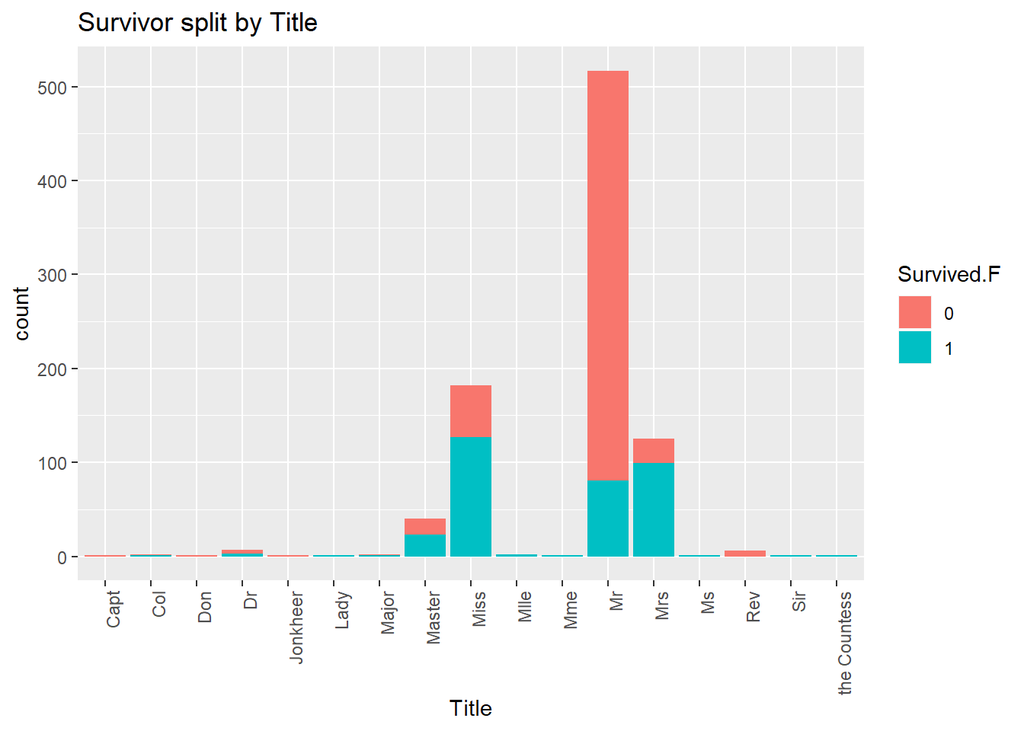

```r
ggplot(data=train, aes(x=Title, fill=Survived.F)) + geom_bar() + theme(axis.text.x = element_text(angle = 90, hjust = 1))  + labs(title="Survivor split by Title")
```

```r
mice_ages <- mice(train[, !names(train) %in% "Survived.F"], method='rf')
mice_out <- complete(mice_ages)
head(mice_out)
```

```
##   Pclass                                                Name Age SibSp
## 1      3                             Braund, Mr. Owen Harris  22     1
## 2      1 Cumings, Mrs. John Bradley (Florence Briggs Thayer)  38     1
## 3      3                              Heikkinen, Miss. Laina  26     0
## 4      1        Futrelle, Mrs. Jacques Heath (Lily May Peel)  35     1
## 5      3                            Allen, Mr. William Henry  35     0
## 6      3                                    Moran, Mr. James  23     0
##   Parch           Ticket    Fare Cabin Embarked  Sex.F Pclass.F Cabin.F
## 1     0        A/5 21171  7.2500     U        S   male        3       U
## 2     0         PC 17599 71.2833     C        C female        1       C
## 3     0 STON/O2. 3101282  7.9250     U        S female        3       U
## 4     0           113803 53.1000     C        S female        1       C
## 5     0           373450  8.0500     U        S   male        3       U
## 6     0           330877  8.4583     U        Q   male        3       U
##   Title
## 1    Mr
## 2   Mrs
## 3  Miss
## 4   Mrs
## 5    Mr
## 6    Mr
```

```r
table(mice_out$Age, useNA = "always")
```

```
##
## 0.42 0.67 0.75 0.83 0.92    1    2    3    4    5    6    7    8    9   10
##    3    1    2    2    1    7   10    7   11    5    3    3    5   10    3
##   11   12   13   14 14.5   15   16   17   18   19   20 20.5   21   22   23
##    5    1    2    9    2    7   21   14   32   32   22    1   32   48   22
## 23.5   24 24.5   25   26   27   28 28.5   29   30 30.5   31   32 32.5   33
##    1   36    1   25   24   23   32    2   24   33    3   20   20    2   21
##   34 34.5   35   36 36.5   37   38   39   40 40.5   41   42   43   44   45
##   21    2   20   23    1   10   17   14   14    2    6   13    5   13   14
## 45.5   46   47   48   49   50   51   52   53   54   55 55.5   56   57   58
##    3    3   11   10    9   11    8    7    1   10    3    1    5    2    5
##   59   60   61   62   63   64   65   66   70 70.5   71   74   80 <NA>
##    3    4    6    5    2    2    5    1    2    1    3    1    2    0
```

```r
train$AgeImp2 <- mice_out$Age
tail(train[,c("Survived.F","Name","AgeImp2")], n=20)
```

```
##     Survived.F                                             Name AgeImp2
## 872          1 Beckwith, Mrs. Richard Leonard (Sallie Monypeny)      47
## 873          0                         Carlsson, Mr. Frans Olof      33
## 874          0                      Vander Cruyssen, Mr. Victor      47
## 875          1            Abelson, Mrs. Samuel (Hannah Wizosky)      28
## 876          1                 Najib, Miss. Adele Kiamie "Jane"      15
## 877          0                    Gustafsson, Mr. Alfred Ossian      20
## 878          0                             Petroff, Mr. Nedelio      19
## 879          0                               Laleff, Mr. Kristo      22
## 880          1    Potter, Mrs. Thomas Jr (Lily Alexenia Wilson)      56
## 881          1     Shelley, Mrs. William (Imanita Parrish Hall)      25
## 882          0                               Markun, Mr. Johann      33
## 883          0                     Dahlberg, Miss. Gerda Ulrika      22
## 884          0                    Banfield, Mr. Frederick James      28
## 885          0                           Sutehall, Mr. Henry Jr      25
## 886          0             Rice, Mrs. William (Margaret Norton)      39
## 887          0                            Montvila, Rev. Juozas      27
## 888          1                     Graham, Miss. Margaret Edith      19
## 889          0         Johnston, Miss. Catherine Helen "Carrie"      15
## 890          1                            Behr, Mr. Karl Howell      26
## 891          0                              Dooley, Mr. Patrick      32
```

```r
ret <- split_train_val(train)
train.sub <- ret[[1]]
validation.sub <- ret[[2]]
val_labels <- ret[[3]]

## Logistic regression
lreg  <- train(Survived.F ~ AgeImp2 + Sex.F + Pclass.F,data=train.sub,method="glm",family=binomial(),trControl=fitControl)
summary(lreg)
```

```
##
## Call:
## NULL
##
## Deviance Residuals:
##     Min       1Q   Median       3Q      Max
## -2.5487  -0.6739  -0.3943   0.5760   2.6078
##
## Coefficients:
##              Estimate Std. Error z value Pr(>|z|)
## (Intercept)  3.256944   0.393259   8.282  < 2e-16 ***
## AgeImp2     -0.024321   0.007834  -3.105  0.00191 **
## Sex.Fmale   -2.687216   0.213147 -12.607  < 2e-16 ***
## Pclass.F2   -0.960761   0.293856  -3.270  0.00108 **
## Pclass.F3   -2.355174   0.277288  -8.494  < 2e-16 ***
## ---
## Signif. codes:  0 '***' 0.001 '**' 0.01 '*' 0.05 '.' 0.1 ' ' 1
##
## (Dispersion parameter for binomial family taken to be 1)
##
##     Null deviance: 943.08  on 711  degrees of freedom
## Residual deviance: 628.96  on 707  degrees of freedom
## AIC: 638.96
##
## Number of Fisher Scoring iterations: 5
```

```r
# let's now predict
lreg_pred <- predict(lreg, validation.sub)
confusionMatrix(lreg_pred, val_labels)
```

```
## Confusion Matrix and Statistics
##
##           Reference
## Prediction  0  1
##          0 93 30
##          1 12 44
##
##                Accuracy : 0.7654
##                  95% CI : (0.6964, 0.8254)
##     No Information Rate : 0.5866
##     P-Value [Acc > NIR] : 3.876e-07
##
##                   Kappa : 0.4982
##  Mcnemar's Test P-Value : 0.008712
##
##             Sensitivity : 0.8857
##             Specificity : 0.5946
##          Pos Pred Value : 0.7561
##          Neg Pred Value : 0.7857
##              Prevalence : 0.5866
##          Detection Rate : 0.5196
##    Detection Prevalence : 0.6872
##       Balanced Accuracy : 0.7402
##
##        'Positive' Class : 0
##
```

```r
auc_val <- auc(val_labels, lreg_pred)
print(auc_val)
```

```
## [1] 0.7401544
```

## Third Logistic Regression

Notice now we have a new variable **Title** as well. Let’s add it to the model. But also notice there are some levels with only one observation. Let’s bin this variable.

What we will find out running this third regression is that the model is going to be affected by multicollinearity most likely between the variable **Title** level **Ms** and **Sex** level **Female** (not surprisingly). We can run a [**vif**](http://www.sthda.com/english/articles/39-regression-model-diagnostics/160-multicollinearity-essentials-and-vif-in-r/) test to detect this more formally.

Please refer also to [**vif**](https://cran.r-project.org/web/packages/olsrr/vignettes/regression_diagnostics.html)

```r
VIP <- c("Capt","Col","Don","Dona","Dr","Jonkheer","Lady","Major",
         "Mlle", "Mme","Rev","Sir","the Countess")

Title.orig <- train$Title
train$Title[train$Title %in% VIP] <- "VIP"
train$Title.F <- as.factor(train$Title)

ret <- split_train_val(train)
train.sub <- ret[[1]]
validation.sub <- ret[[2]]
val_labels <- ret[[3]]

## Logistic regression
lreg  <- train(Survived.F ~ AgeImp2 + Sex.F + Pclass.F + Title.F,data=train.sub,method="glm",family=binomial(),trControl=fitControl)
summary(lreg)
```

```
##
## Call:
## NULL
##
## Deviance Residuals:
##     Min       1Q   Median       3Q      Max
## -2.4141  -0.6701  -0.3509   0.5482   2.4886
##
## Coefficients: (1 not defined because of singularities)
##               Estimate Std. Error z value Pr(>|z|)
## (Intercept)  18.938619 593.651052   0.032 0.974550
## AgeImp2      -0.008390   0.008739  -0.960 0.337037
## Sex.Fmale   -16.686779 593.650904  -0.028 0.977575
## Pclass.F2    -0.978053   0.312574  -3.129 0.001754 **
## Pclass.F3    -2.380213   0.294078  -8.094 5.78e-16 ***
## Title.FMiss -16.190421 593.651090  -0.027 0.978242
## Title.FMr    -2.376527   0.471504  -5.040 4.65e-07 ***
## Title.FMrs  -15.870639 593.651163  -0.027 0.978672
## Title.FMs           NA         NA      NA       NA
## Title.FVIP   -3.087525   0.818605  -3.772 0.000162 ***
## ---
## Signif. codes:  0 '***' 0.001 '**' 0.01 '*' 0.05 '.' 0.1 ' ' 1
##
## (Dispersion parameter for binomial family taken to be 1)
##
##     Null deviance: 943.08  on 711  degrees of freedom
## Residual deviance: 599.16  on 703  degrees of freedom
## AIC: 617.16
##
## Number of Fisher Scoring iterations: 14
```

```r
# let's now predict
lreg_pred <- predict(lreg, validation.sub)
confusionMatrix(lreg_pred, val_labels)
```

```
## Confusion Matrix and Statistics
##
##           Reference
## Prediction  0  1
##          0 90 25
##          1 15 49
##
##                Accuracy : 0.7765
##                  95% CI : (0.7084, 0.8353)
##     No Information Rate : 0.5866
##     P-Value [Acc > NIR] : 6.711e-08
##
##                   Kappa : 0.5299
##  Mcnemar's Test P-Value : 0.1547
##
##             Sensitivity : 0.8571
##             Specificity : 0.6622
##          Pos Pred Value : 0.7826
##          Neg Pred Value : 0.7656
##              Prevalence : 0.5866
##          Detection Rate : 0.5028
##    Detection Prevalence : 0.6425
##       Balanced Accuracy : 0.7597
##
##        'Positive' Class : 0
##
```

```r
auc_val <- auc(val_labels, lreg_pred)
print(auc_val)
```

```
## [1] 0.7596525
```

```r
glm.model <- glm(Survived.F ~ AgeImp2 + Sex.F + Pclass.F + Title.F, data = train.sub, family = binomial())
vif(glm.model)
```

```
##                  GVIF Df GVIF^(1/(2*Df))
## AgeImp2  1.690202e+00  1        1.300078
## Sex.F    8.288104e+06  1     2878.906766
## Pclass.F 1.499285e+00  2        1.106550
## Title.F  1.205340e+07  4        7.676066
```

```r
# put back the original Title given we have a multicollinearity problem
train$Title <- Title.orig
train$Title.F <- as.factor(train$Title)
```

This didn’t quite work. As said earlier, it seems the level **TitleMs** is multicollinear with **Sex**. What can we do? One solution would be to remove one of the variable **Title** or **Sex** but Let’s try a more advanced binning technique based on Random Forest using the **tree.bins** R package.

```r
sample.df <- train %>% select(Survived.F, Title.F)
both <- tree.bins(data = sample.df, y = Survived.F, bin.nm = "bin#.", control = rpart.control(cp = .001), return = "both")
head(both$new.fctrs, n=10)
```

```
##     Survived.F Title.F
##  1:          0  bin#.1
##  2:          1  bin#.2
##  3:          1  bin#.2
##  4:          1  bin#.2
##  5:          0  bin#.1
##  6:          0  bin#.1
##  7:          0  bin#.1
##  8:          0  bin#.2
##  9:          1  bin#.2
## 10:          1  bin#.2
```

```r
str(sample.df$Title.F)
```

```
##  Factor w/ 17 levels "Capt","Col","Don",..: 12 13 9 13 12 12 12 8 13 13 ...
```

```r
train$Title.F <- both$new.fctrs$Title.F


# let's try again the regression
ret <- split_train_val(train)
train.sub <- ret[[1]]
validation.sub <- ret[[2]]
val_labels <- ret[[3]]

## Logistic regression
lreg  <- train(Survived.F ~ AgeImp2 + Sex.F + Pclass.F + Title.F,data=train.sub,method="glm",family=binomial(),trControl=fitControl)
summary(lreg)
```

```
##
## Call:
## NULL
##
## Deviance Residuals:
##     Min       1Q   Median       3Q      Max
## -2.4228  -0.6724  -0.3498   0.5752   2.5238
##
## Coefficients:
##                  Estimate Std. Error z value Pr(>|z|)
## (Intercept)      0.844892   0.638325   1.324  0.18563
## AgeImp2         -0.010844   0.008298  -1.307  0.19130
## Sex.Fmale       -0.942852   0.414033  -2.277  0.02277 *
## Pclass.F2       -0.926664   0.303908  -3.049  0.00229 **
## Pclass.F3       -2.339612   0.287596  -8.135 4.12e-16 ***
## `Title.Fbin#.2`  2.057222   0.436578   4.712 2.45e-06 ***
## ---
## Signif. codes:  0 '***' 0.001 '**' 0.01 '*' 0.05 '.' 0.1 ' ' 1
##
## (Dispersion parameter for binomial family taken to be 1)
##
##     Null deviance: 943.08  on 711  degrees of freedom
## Residual deviance: 607.08  on 706  degrees of freedom
## AIC: 619.08
##
## Number of Fisher Scoring iterations: 5
```

```r
# let's now predict
lreg_pred <- predict(lreg, validation.sub)
confusionMatrix(lreg_pred, val_labels)
```

```
## Confusion Matrix and Statistics
##
##           Reference
## Prediction  0  1
##          0 90 23
##          1 15 51
##
##                Accuracy : 0.7877
##                  95% CI : (0.7205, 0.8452)
##     No Information Rate : 0.5866
##     P-Value [Acc > NIR] : 1.026e-08
##
##                   Kappa : 0.5552
##  Mcnemar's Test P-Value : 0.2561
##
##             Sensitivity : 0.8571
##             Specificity : 0.6892
##          Pos Pred Value : 0.7965
##          Neg Pred Value : 0.7727
##              Prevalence : 0.5866
##          Detection Rate : 0.5028
##    Detection Prevalence : 0.6313
##       Balanced Accuracy : 0.7732
##
##        'Positive' Class : 0
##
```

```r
auc_val <- auc(val_labels, lreg_pred)
print(auc_val)
```

```
## [1] 0.773166
```

The regression now works after **tree.bins** created two bins out of the **Title** variable and managed to increase the prediction power.

## Random Forest

Lastly we can run **Random Forest** on the same set of features/variables to check if we can have a better prediction (the model at this stage is very simple so we may not have any real improvement, as the old adage goes **“do not use a sledgehammer to crack a nut”**)

```r
lrf  <- train(Survived.F ~ AgeImp2 + Sex.F + Pclass.F + Title.F,data=train.sub,method="rf",family=binomial(),trControl=fitControl, tuneGrid = data.frame(mtry = 5))
lrf
```

```
## Random Forest
##
## 712 samples
##   4 predictor
##   2 classes: '0', '1'
##
## No pre-processing
## Resampling: Cross-Validated (4 fold)
## Summary of sample sizes: 534, 534, 534, 534
## Resampling results:
##
##   Accuracy   Kappa
##   0.7808989  0.5204225
##
## Tuning parameter 'mtry' was held constant at a value of 5
```

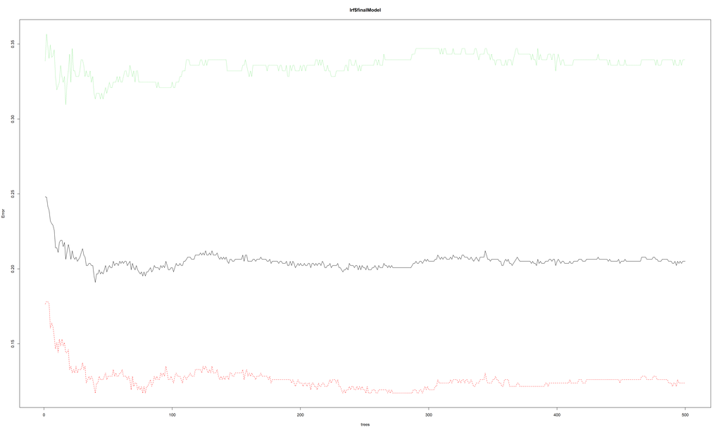

```r
plot(lrf$finalModel)
```

```r
# let's now predict
lrf_pred <- predict(lrf, validation.sub)
confusionMatrix(lrf_pred, val_labels)
```

```
## Confusion Matrix and Statistics
##
##           Reference
## Prediction  0  1
##          0 91 22
##          1 14 52
##
##                Accuracy : 0.7989
##                  95% CI : (0.7326, 0.855)
##     No Information Rate : 0.5866
##     P-Value [Acc > NIR] : 1.377e-09
##
##                   Kappa : 0.5786
##  Mcnemar's Test P-Value : 0.2433
##
##             Sensitivity : 0.8667
##             Specificity : 0.7027
##          Pos Pred Value : 0.8053
##          Neg Pred Value : 0.7879
##              Prevalence : 0.5866
##          Detection Rate : 0.5084
##    Detection Prevalence : 0.6313
##       Balanced Accuracy : 0.7847
##
##        'Positive' Class : 0
##
```

```r
auc_val <- auc(val_labels, lrf_pred)
print(auc_val)
```

```
## [1] 0.7846847
```

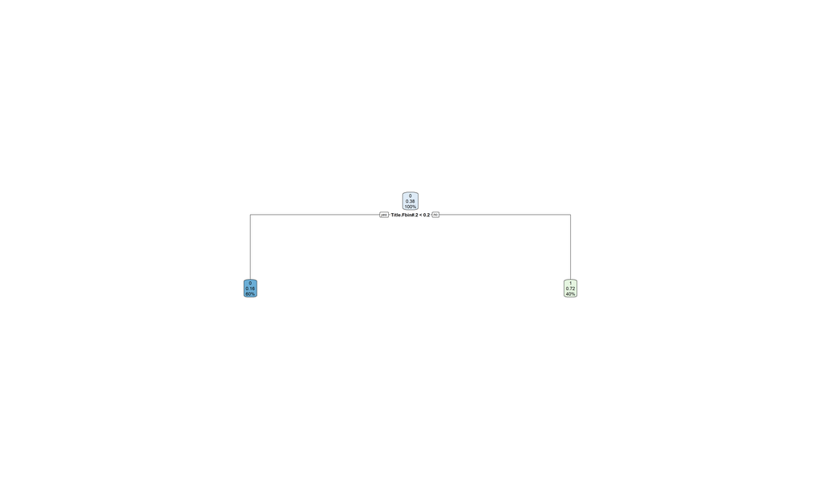

```r
# Let's use a slightly different rf library to plot the potential tree
preProcessInTrain<-c("center", "scale")
metric_used<-"Accuracy"
model <- train(
  Survived.F ~ AgeImp2 + Sex.F + Pclass.F + Title.F, data = train,
  method = "rpart",
  trControl = fitControl,
  metric=metric_used,
  tuneLength = 10,
  preProc = preProcessInTrain
)
library(rpart.plot)
rpart.plot(model$finalModel)
```

## Age Binning

So far we bin to “join” levels but maintain the same statistical property of the overall feature distribution (**tree.bins**).

We could also bin the **Age** variable in brackets to check if we can improve the overall predictions.

```r
AgeBracketF<-function(X){
  if(X > 50){
    return("old")
  }
  else if(X<=50 & X>18){
   return("adult")
  }
  else if(X<=18 & X>13){
   return("teenager")
  }
  else{
    return("child")
  }
}

train$AgeBracket<- sapply(train$AgeImp2, function(X) AgeBracketF(X))
train$AgeBracket.F <- as.factor(train$AgeBracket)

# let's try again the regression
ret <- split_train_val(train)
train.sub <- ret[[1]]
validation.sub <- ret[[2]]
val_labels <- ret[[3]]

## Logistic regression
lreg  <- train(Survived.F ~ AgeBracket.F + Sex.F + Pclass.F + Title.F,data=train.sub,method="glm",family=binomial(),trControl=fitControl)
summary(lreg)
```

```
##
## Call:
## NULL
##
## Deviance Residuals:
##     Min       1Q   Median       3Q      Max
## -2.3529  -0.6913  -0.3688   0.5521   2.5499
##
## Coefficients:
##                      Estimate Std. Error z value Pr(>|z|)
## (Intercept)           0.09881    0.52095   0.190  0.84957
## AgeBracket.Fchild    -0.45064    0.38930  -1.158  0.24704
## AgeBracket.Fold      -0.55741    0.38409  -1.451  0.14671
## AgeBracket.Fteenager -0.26206    0.34617  -0.757  0.44903
## Sex.Fmale            -0.50911    0.47301  -1.076  0.28179
## Pclass.F2            -0.89924    0.30328  -2.965  0.00303 **
## Pclass.F3            -2.24378    0.27639  -8.118 4.73e-16 ***
## `Title.Fbin#.2`       2.60454    0.51618   5.046 4.52e-07 ***
## ---
## Signif. codes:  0 '***' 0.001 '**' 0.01 '*' 0.05 '.' 0.1 ' ' 1
##
## (Dispersion parameter for binomial family taken to be 1)
##
##     Null deviance: 943.08  on 711  degrees of freedom
## Residual deviance: 605.24  on 704  degrees of freedom
## AIC: 621.24
##
## Number of Fisher Scoring iterations: 5
```

```r
# let's now predict
lreg_pred <- predict(lreg, validation.sub)
confusionMatrix(lreg_pred, val_labels)
```

```
## Confusion Matrix and Statistics
##
##           Reference
## Prediction  0  1
##          0 90 23
##          1 15 51
##
##                Accuracy : 0.7877
##                  95% CI : (0.7205, 0.8452)
##     No Information Rate : 0.5866
##     P-Value [Acc > NIR] : 1.026e-08
##
##                   Kappa : 0.5552
##  Mcnemar's Test P-Value : 0.2561
##
##             Sensitivity : 0.8571
##             Specificity : 0.6892
##          Pos Pred Value : 0.7965
##          Neg Pred Value : 0.7727
##              Prevalence : 0.5866
##          Detection Rate : 0.5028
##    Detection Prevalence : 0.6313
##       Balanced Accuracy : 0.7732
##
##        'Positive' Class : 0
##
```

```r
auc_val <- auc(val_labels, lreg_pred)
print(auc_val)
```

```
## [1] 0.773166
```

### Cabin

```r
## Logistic regression
table(train$Ticket)
```

```
##
##             110152             110413             110465
##                  3                  3                  2
##             110564             110813             111240
##                  1                  1                  1
##             111320             111361             111369
##                  1                  2                  1
##             111426             111427             111428
##                  1                  1                  1
##             112050             112052             112053
##                  1                  1                  1
##             112058             112059             112277
##                  1                  1                  1
##             112379             113028             113043
##                  1                  1                  1
```

[output cut: 440 more lines]

```r
lreg  <- train(Survived.F ~ AgeBracket.F + Pclass.F + Title.F + Fare,data=train.sub,method="glm",family=binomial(),trControl=fitControl)
summary(lreg)
```

```
##
## Call:
## NULL
##
## Deviance Residuals:
##     Min       1Q   Median       3Q      Max
## -2.3547  -0.6922  -0.3702   0.5551   2.5476
##
## Coefficients:
##                        Estimate Std. Error z value Pr(>|z|)
## (Intercept)          -0.4309905  0.2867432  -1.503  0.13283
## AgeBracket.Fchild    -0.6794785  0.3287968  -2.067  0.03878 *
## AgeBracket.Fold      -0.5593272  0.3863331  -1.448  0.14768
## AgeBracket.Fteenager -0.2717914  0.3461775  -0.785  0.43238
## Pclass.F2            -0.8795607  0.3360249  -2.618  0.00886 **
## Pclass.F3            -2.2172613  0.3228301  -6.868  6.5e-12 ***
## `Title.Fbin#.2`       3.0956140  0.2416365  12.811  < 2e-16 ***
## Fare                  0.0002843  0.0023109   0.123  0.90207
## ---
## Signif. codes:  0 '***' 0.001 '**' 0.01 '*' 0.05 '.' 0.1 ' ' 1
##
## (Dispersion parameter for binomial family taken to be 1)
##
##     Null deviance: 943.08  on 711  degrees of freedom
## Residual deviance: 606.38  on 704  degrees of freedom
## AIC: 622.38
##
## Number of Fisher Scoring iterations: 5
```

```r
# let's now predict
lreg_pred <- predict(lreg, validation.sub)
confusionMatrix(lreg_pred, val_labels)
```

```
## Confusion Matrix and Statistics
##
##           Reference
## Prediction  0  1
##          0 91 26
##          1 14 48
##
##                Accuracy : 0.7765
##                  95% CI : (0.7084, 0.8353)
##     No Information Rate : 0.5866
##     P-Value [Acc > NIR] : 6.711e-08
##
##                   Kappa : 0.528
##  Mcnemar's Test P-Value : 0.08199
##
##             Sensitivity : 0.8667
##             Specificity : 0.6486
##          Pos Pred Value : 0.7778
##          Neg Pred Value : 0.7742
##              Prevalence : 0.5866
##          Detection Rate : 0.5084
##    Detection Prevalence : 0.6536
##       Balanced Accuracy : 0.7577
##
##        'Positive' Class : 0
##
```

```r
auc_val <- auc(val_labels, lreg_pred)
print(auc_val)
```

```
## [1] 0.7576577
```

## Conclusions

In this lecture we investigated some powerful way to **impute** and **binning** data.